# EXAM 03 PRACTICE

- Show All Code
- Hide All Code

## **Spring-Mass Equation Problems**

**Formulas**

The undamped, undriven spring-mass system is represented by:

$$y'' + \frac{k}{m} y = 0$$

Where:

- $k$ is the spring constant, indicating the stiffness of the spring.
- $m$ is the mass of the object attached to the spring.
- $y$ is the displacement of the mass from its equilibrium position.

The general solution to this differential equation is:

$$y_h = c_1 \cos \left( \sqrt{\frac{k}{m}} \, t \right) + c_2 \sin \left( \sqrt{\frac{k}{m}} \, t \right)$$

Where:

- $y_h$ is the general solution to the homogeneous equation.
- $c_1$ and $c_2$ are constants determined by initial conditions.
- $\sqrt{\frac{k}{m}}$ is the natural angular frequency of the undamped system, often denoted as $\omega = \sqrt{\frac{k}{m}}$.

For a damped, driven spring-mass system, we use:

$$y'' + \frac{c}{m} y' + \frac{k}{m} y = \frac{1}{m} F(t)$$

where:

- $m$: Mass of the object.
- $k$: Spring constant, measuring the stiffness of the spring. A higher $k$ indicates a stiffer spring.
- $c$: Damping constant, representing resistance (e.g., due to friction or air resistance) opposing the motion. A higher $c$ implies greater resistance and faster energy dissipation.
- $y(t)$: Displacement of the mass from its equilibrium position at time $t$.
- $F(t)$: External force applied to the system as a function of time.

The terms in the equation represent:

- $y''$: Acceleration of the mass.
- $\frac{c}{m} y'$: Damping term, proportional to the velocity $y'$ and damping constant $c$.
- $\frac{k}{m} y$: Restoring force term, proportional to displacement $y$ and spring constant $k$.
- $\frac{1}{m} F(t)$: External force per unit mass acting on the system. :::

**Problem**

For the given initial-value problem $y(0) = y'(0) = 0$, solve for $y(t)$ in an undamped spring-mass system with the specified parameters. Additionally, determine the maximum displacement of the mass, state if beats or resonance are present, and sketch the solution.

Given parameters:

- $m = 1$
- $k = 25$
- $f(t) = 0.01 \cos(5t)$

**Solution:**

#### Solve the Homogeneous Equation

The corresponding homogeneous equation is:

$$y_h'' + 25y_h = 0$$

The characteristic equation is:

$$r^2 + 25 = 0 \quad \Rightarrow \quad r = \pm 5i$$

The general solution to the homogeneous equation is:

$$y_h(t) = C_1 \cos(5t) + C_2 \sin(5t)$$

#### Find the Particular Solution

The non-homogeneous term is $f(t) = \frac{1}{100} \cos(5t)$. Since this term has the same frequency as the homogeneous solution, **resonance** occurs.

To account for resonance, assume a particular solution of the form:

$$y_p(t) = t \left( A \cos(5t) + B \sin(5t) \right)$$

#### Compute the Derivatives of $y_p(t)$

1. **First Derivative $y_p'(t)$:**

   Using the product rule:

   $$\begin{aligned}
   y_p'(t) &= A \cos(5t) + B \sin(5t) + t \left( -5A \sin(5t) + 5B \cos(5t) \right) \\
   &= A \cos(5t) + B \sin(5t) - 5A t \sin(5t) + 5B t \cos(5t)
   \end{aligned}$$
2. **Second Derivative $y_p''(t)$:**

   Differentiating $y_p'(t)$:

   $$\begin{aligned}
   y_p''(t) &= -5A \sin(5t) + 5B \cos(5t) - 5A \sin(5t) + 5B \cos(5t) \\
   &\quad - 25A t \cos(5t) - 25B t \sin(5t) \\
   &= -10A \sin(5t) + 10B \cos(5t) - 25A t \cos(5t) - 25B t \sin(5t)
   \end{aligned}$$

#### Substitute into the Original Equation

$$y_p''(t) + 25 y_p(t) = \frac{1}{100} \cos(5t)$$

Plugging in the expressions:

$$\begin{aligned}
&\left[ -10A \sin(5t) + 10B \cos(5t) - 25A t \cos(5t) - 25B t \sin(5t) \right] \\
&\quad + 25 \left[ A t \cos(5t) + B t \sin(5t) \right] = \frac{1}{100} \cos(5t)
\end{aligned}$$

Simplifying:

$$-10A \sin(5t) + 10B \cos(5t) = \frac{1}{100} \cos(5t)$$

#### Equate Coefficients and Solve for $A$ and $B$

1. Coefficient of $\sin(5t)$:

   $$-10A = 0 \quad \Rightarrow \quad A = 0$$
2. Coefficient of $\cos(5t)$:

   $$10B = \frac{1}{100} \quad \Rightarrow \quad B = \frac{1}{1000}$$

#### Write the Particular Solution

Substitute $A = 0$ and $B = \frac{1}{1000}$:

$$y_p(t) = t \left( 0 \cdot \cos(5t) + \frac{1}{1000} \sin(5t) \right) = \frac{t}{1000} \sin(5t)$$

#### Form the General Solution

$$y(t) = y_h(t) + y_p(t) = C_1 \cos(5t) + C_2 \sin(5t) + \frac{t}{1000} \sin(5t)$$

#### Apply Initial Conditions

Given $y(0) = 0$ and $y'(0) = 0$:

1. **At $t = 0$:**

   $$y(0) = C_1 \cos(0) + C_2 \sin(0) + \frac{0}{1000} \sin(0) = C_1$$

   Since $y(0) = 0$:

   $$C_1 = 0$$
2. **First Derivative $y'(t)$:**

   $$\begin{aligned}
   y'(t) &= -5 C_1 \sin(5t) + 5 C_2 \cos(5t) + \frac{d}{dt} \left( \frac{t}{1000} \sin(5t) \right) \\
   &= 5 C_2 \cos(5t) + \frac{1}{1000} \sin(5t) + \frac{5t}{1000} \cos(5t)
   \end{aligned}$$

   **At $t = 0$:**

   $$y'(0) = 5 C_2 \cos(0) + \frac{1}{1000} \sin(0) + \frac{5 \cdot 0}{1000} \cos(0) = 5 C_2$$

   Since $y'(0) = 0$:

   $$C_2 = 0$$

#### Final Solution

With $C_1 = 0$ and $C_2 = 0$, the solution simplifies to:

$$y(t) = \frac{t}{1000} \sin(5t) = \frac{t}{10^3} \sin(5t)$$

#### Maximum Displacement

Since resonance occurs, the amplitude of $y(t) = \frac{t}{1000} \sin(5t)$ grows without bound as $t \to \infty$. So the maximum displacement increases indefinitely over time due to resonance.

#### Presence of Beats or Resonance

**Resonance** is present because the forcing frequency matches the natural frequency of the system.

#### Graph

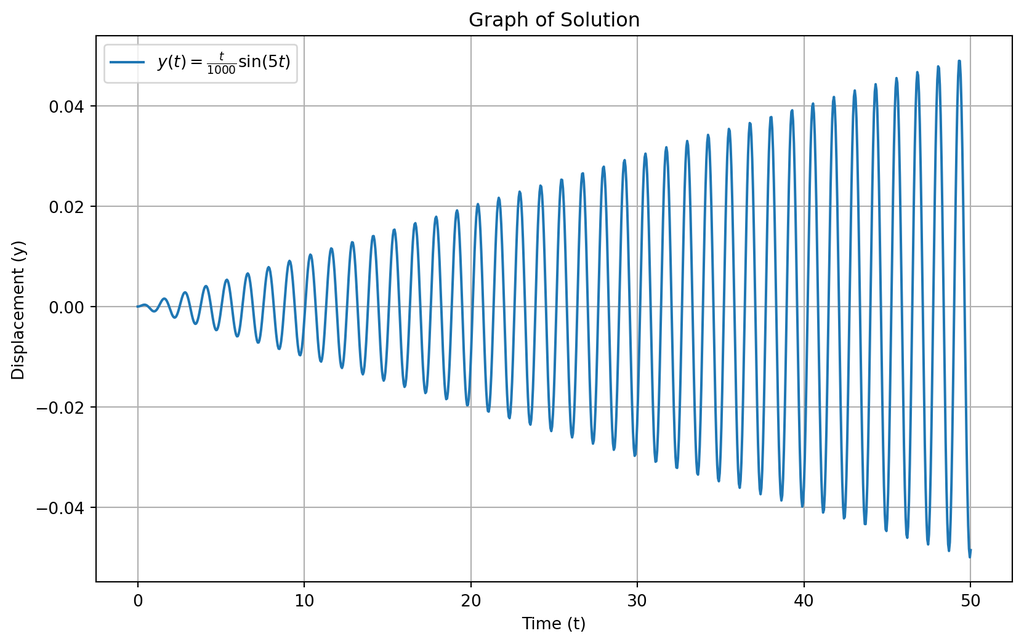

```python
import numpy as np
import matplotlib.pyplot as plt

t = np.linspace(0, 50, 1000)

y = (t / 1000) * np.sin(5 * t)

plt.figure(figsize=(10, 6))
plt.plot(t, y, label=r"$y(t) = \frac{t}{1000} \sin(5t)$")
plt.xlabel("Time (t)")
plt.ylabel("Displacement (y)")
plt.title("Graph of Solution")
plt.legend()
plt.grid(True)
plt.show()
```

### Final Solution

$$y(t) = \frac{t}{1000} \sin(5t)$$

The system exhibits **resonance**, leading to an unbounded increase in displacement over time.

**Problem**

In the given initial-value problem, solve for $y(t)$ in an undamped spring-mass system with the specified parameters. Additionally, determine the maximum displacement of the mass, state if beats or resonance are present, and sketch the solution.

Given parameters:

- $m = 1$
- $k = 36$
- $f(t) = 2 e^{6t}$
- Initial conditions: $y(0) = 0$ and $y'(0) = 0$

**Solution:**

### Solve the Homogeneous Equation

The homogeneous equation is:

$$y_h'' + 36 y_h = 0$$

The characteristic equation is:

$$r^2 + 36 = 0 \quad \Rightarrow \quad r = \pm 6i$$

The general solution to the homogeneous equation is:

$$y_h(t) = C_1 \cos(6t) + C_2 \sin(6t)$$

### Find the Particular Solution

The non-homogeneous term is $f(t) = 2 e^{6t}$. Since this is an exponential function and does not overlap with the homogeneous solution, assume a particular solution of the form:

$$y_p(t) = A e^{6t}$$

### Compute the Derivatives of $y_p(t)$

1. **First Derivative $y_p'(t)$:**

   $$y_p'(t) = 6 A e^{6t}$$
2. **Second Derivative $y_p''(t)$:**

   $$y_p''(t) = 36 A e^{6t}$$

### Substitute into the Original Equation

Substitute $y_p(t)$, $y_p'(t)$, and $y_p''(t)$ into the differential equation:

$$y_p'' + 36 y_p = 2 e^{6t}$$

Substitute the expressions:

$$36 A e^{6t} + 36 A e^{6t} = 2 e^{6t}$$

Simplify:

$$72 A e^{6t} = 2 e^{6t}$$

Divide both sides by $e^{6t}$:

$$72 A = 2$$

### Solve for $A$

$$A = \frac{2}{72} = \frac{1}{36}$$

### Particular Solution

$$y_p(t) = \frac{1}{36} e^{6t}$$

### General Solution

$$y(t) = y_h(t) + y_p(t) = C_1 \cos(6t) + C_2 \sin(6t) + \frac{1}{36} e^{6t}$$

### Apply Initial Conditions

Given $y(0) = 0$ and $y'(0) = 0$, we can solve for $C_1$ and $C_2$.

1. **At $t = 0$:**

   $$y(0) = C_1 \cos(0) + C_2 \sin(0) + \frac{1}{36} e^{0} = C_1 + \frac{1}{36}$$

   Since $y(0) = 0$:

   $$C_1 + \frac{1}{36} = 0 \quad \Rightarrow \quad C_1 = -\frac{1}{36}$$
2. **First Derivative $y'(t)$:**

   Calculate $y'(t)$:

   $$y'(t) = -6 C_1 \sin(6t) + 6 C_2 \cos(6t) + \frac{1}{36} \cdot 6 e^{6t} = -6 C_1 \sin(6t) + 6 C_2 \cos(6t) + \frac{1}{6} e^{6t}$$

   At $t = 0$:

   $$y'(0) = -6 C_1 \sin(0) + 6 C_2 \cos(0) + \frac{1}{6} e^{0} = 6 C_2 + \frac{1}{6}$$

   Since $y'(0) = 0$:

   $$6 C_2 + \frac{1}{6} = 0 \quad \Rightarrow \quad C_2 = -\frac{1}{36}$$

### Final Solution

Substitute $C_1 = -\frac{1}{36}$ and $C_2 = -\frac{1}{36}$:

$$y(t) = -\frac{1}{36} \cos(6t) - \frac{1}{36} \sin(6t) + \frac{1}{36} e^{6t}$$

### Determine Maximum Displacement

The term $\frac{1}{36} e^{6t}$ grows exponentially as $t \to \infty$, leading to an unbounded increase in displacement. Therefore, the maximum displacement increases without bound over time.

### Presence of Beats or Resonance

- **Resonance is not present** in this system, as the forcing frequency does not match the natural frequency.
- **Beats are not present** since there are no two competing frequencies close to each other.

### Graph

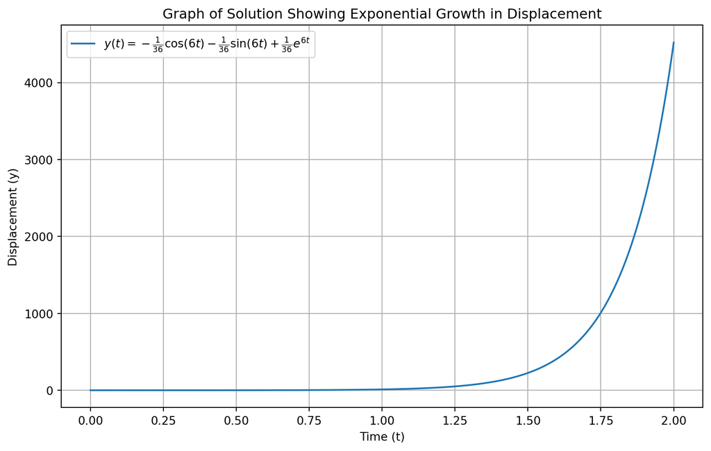

```python
t = np.linspace(0, 2, 1000)
y = (-1/36) * np.cos(6 * t) - (1/36) * np.sin(6 * t) + (1/36) * np.exp(6 * t)

plt.figure(figsize=(10, 6))
plt.plot(t, y, label=r"$y(t) = -\frac{1}{36} \cos(6t) - \frac{1}{36} \sin(6t) + \frac{1}{36} e^{6t}$")
plt.xlabel("Time (t)")
plt.ylabel("Displacement (y)")
plt.title("Graph of Solution Showing Exponential Growth in Displacement")
plt.legend()
plt.grid(True)
plt.show()
```

### Final Answer

The solution to the initial-value problem is:

$$y(t) = -\frac{1}{36} \cos(6t) - \frac{1}{36} \sin(6t) + \frac{1}{36} e^{6t}$$

- The system does not exhibit resonance or beats.
- The maximum displacement grows exponentially due to the $\frac{1}{36} e^{6t}$ term. :::

## **Higher-Order Homogeneous Differential Equation Problems**

**Problem**

$$y''' - 2y'' - y' + 2y = 0$$

**Solution:**

### Write the Characteristic Equation

Since this is a third-order differential equation, the characteristic equation is:

$$r^3 - 2r^2 - r + 2 = 0$$

### Factor the Characteristic Polynomial

1. Testing $r = 1$:

   $$1^3 - 2(1)^2 - 1 + 2 = 1 - 2 - 1 + 2 = 0$$

   Since $r = 1$ is a root, factor $r - 1$ out of the polynomial.
2. Divide $r^3 - 2r^2 - r + 2$ by $r - 1$ using synthetic division or polynomial division:
   - Dividing $r^3 - 2r^2 - r + 2$ by $r - 1$:
     $$r^3 - 2r^2 - r + 2 = (r - 1)(r^2 - r - 2)$$
3. Factor $r^2 - r - 2$:
   $$r^2 - r - 2 = (r - 2)(r + 1)$$

The characteristic equation factors as:

$$(r - 1)(r - 2)(r + 1) = 0$$

### Solve for the Roots

The roots of the characteristic equation are:

$$r = 1, \quad r = 2, \quad r = -1$$

### Write the General Solution

Since all the roots are real and distinct, the general solution for $y(t)$ is:

$$y(t) = C_1 e^{t} + C_2 e^{2t} + C_3 e^{-t}$$

where $C_1$, $C_2$, and $C_3$ are constants determined by initial conditions.

### Final Answer

The general solution to the differential equation is:

$$y(t) = C_1 e^{t} + C_2 e^{2t} + C_3 e^{-t}$$

**Problem**

$$y^{(4)} + 4y''' + 6y'' + 4y' + y = 0$$

**Solution:**

### Write the Characteristic Equation

For a differential equation of the form $y^{(4)} + 4y''' + 6y'' + 4y' + y = 0$, replace each derivative with powers of $r$, giving:

$$r^4 + 4r^3 + 6r^2 + 4r + 1 = 0$$

### Recognize the Binomial Expansion

Notice that the characteristic polynomial:

$$r^4 + 4r^3 + 6r^2 + 4r + 1$$

resembles the binomial expansion of $(r + 1)^4$, which expands to:

$$(r + 1)^4 = r^4 + 4r^3 + 6r^2 + 4r + 1$$

Rewrite the characteristic equation as:

$$(r + 1)^4 = 0$$

### Solve for the Roots

The equation $(r + 1)^4 = 0$ has a repeated root:

$$r = -1$$

with multiplicity 4.

### Write the General Solution

Since $r = -1$ is a root with multiplicity 4, the general solution is:

$$y(t) = (C_1 + C_2 t + C_3 t^2 + C_4 t^3)e^{-t}$$

where $C_1$, $C_2$, $C_3$, and $C_4$ are constants determined by initial conditions.

### Final Answer

$$y(t) = (C_1 + C_2 t + C_3 t^2 + C_4 t^3)e^{-t}$$

## **Eigenvectors/Eigenvalues Problems**

**Problem**

**Problem**

## **Nonhomogeneous Second-Order Differential Equation Problems**

**Problem**

**Problem**

## **Variation of Parameters Problems**

**Formula**

**Theorem 4.4.2 - Variation of Parameters Method**

For the differential equation

$$y'' + a_1 y' + a_0 y = f(t),$$

where $f$ is continuous, assume that $y_1$ and $y_2$ are linearly independent solutions of the corresponding homogeneous equation

$$y'' + a_1 y' + a_0 y = 0.$$

Then, a particular solution to the non-homogeneous equation is $y_p = u_1 y_1 + u_2 y_2$, where $u_1$ and $u_2$ satisfy

$$u_1 = \int \frac{y_2 f}{y_2 y_1' - y_1 y_2'} \, dt \quad \text{and} \quad u_2 = \int \frac{y_1 f}{y_1 y_2' - y_2 y_1'} \, dt.$$

**Problem**

Solve the non-homogeneous linear differential equation:

$$y'' - 2 y' + y = \dfrac{e^{t}}{t}, \quad t > 0$$

using the **Variation of Parameters** method.

**Solution:**

### Solve the Homogeneous Equation

First, find the general solution to the corresponding homogeneous equation:

$$y'' - 2 y' + y = 0$$

**Characteristic Equation:**

Replace $y''$ with $r^2$, $y'$ with $r$, and $y$ with 1:

$$r^2 - 2 r + 1 = 0$$

**Solve for $r$:**

Factor the quadratic equation:

$$(r - 1)^2 = 0$$

We have a **repeated root** at $r = 1$.

**General Solution to the Homogeneous Equation:**

For a repeated root $r = 1$, the general solution is:

$$y_h(t) = C_1 e^{r t} + C_2 t e^{r t} = C_1 e^{t} + C_2 t e^{t}$$

where $C_1$ and $C_2$ are arbitrary constants.

### Step 2: Identify $y_1(t)$ and $y_2(t)$

From the homogeneous solution, the linearly independent solutions are:

- $y_1(t) = e^{t}$
- $y_2(t) = t e^{t}$

### Compute the Wronskian $W(y_1, y_2)(t)$

The Wronskian is:

$$W(y_1, y_2)(t) = y_1(t) y_2'(t) - y_1'(t) y_2(t)$$

**Compute $y_1'(t)$ and $y_2'(t)$:**

- $y_1'(t) = e^{t}$
- $y_2'(t) = \dfrac{d}{dt} [ t e^{t} ] = e^{t} + t e^{t} = e^{t} (1 + t)$

**Compute the Wronskian:**

$$\begin{aligned}
W(y_1, y_2)(t) &= y_1(t) y_2'(t) - y_1'(t) y_2(t) \\
&= e^{t} \cdot e^{t} (1 + t) - e^{t} \cdot t e^{t} \\
&= e^{2t} (1 + t) - e^{2t} t \\
&= e^{2t} (1 + t - t) \\
&= e^{2t}
\end{aligned}$$

$$W(y_1, y_2)(t) = e^{2t}$$

### Compute $u_1(t)$ and $u_2(t)$

**Compute $u_1(t)$:**

**Compute $u_2(t)$:**

Since $t > 0$, drop the absolute value:

$$u_2(t) = -\ln t + C_2$$

### Construct the Particular Solution $y_p(t)$

The particular solution is:

$$\begin{aligned}
y_p(t) &= u_1(t) y_1(t) + u_2(t) y_2(t) \\
&= [ t + C_1 ] \cdot e^{t} + [ -\ln t + C_2 ] \cdot t e^{t} \\
&= e^{t} \left( t + C_1 - t \ln t + C_2 t \right)
\end{aligned}$$

Since the constants $C_1$ and $C_2$ will be absorbed into the homogeneous solution, we can set $C_1 = 0$ and $C_2 = 0$ for the particular solution:

### **Final Answer**

**Problem**

## **Mixing Problems**

**Problem**

Brine is entering a 25-m$^3$ tank at flow rate of 0.5 m$^3$/min and at a concentration of 6 g/m$^3$. The uniformly mixed solution exits the tank at a rate of 0.25 m$^3$/min. Assume that initially there are 5 m$^3$ of solution in the tank at a concentration of 25 g/m$^3$.

1. State an IVP that is satisfied by the amount of salt $A(t)$ in grams in the tank at time $t$.
2. Solve the IVP stated in (a). For what values of $t$ is this problem valid? Why?
3. At exactly what time will the least amount of salt be present in the tank? How much salt will there be at that time?
4. Plot a direction field for the IVP stated in (a), including a plot of the solution. Discuss why this direction field and the solution make sense in the physical context of the problem.

**Solution:**

### (a) State an IVP that is satisfied by the amount of salt $A(t)$ in grams in the tank at time $t$.

Set up a differential equation to represent the amount of salt $A(t)$ in the tank at time $t$.

- **Flow of brine into the tank:**
  - Inflow rate: 0.5 m$^3$/min
  - Concentration of inflow: 6 g/m$^3$
  - **Salt inflow rate:**
    $$\text{Inflow rate of salt} = (0.5 \, \text{m}^3/\text{min}) \cdot (6 \, \text{g/m}^3) = 3 \, \text{g/min}$$
- **Flow of solution out of the tank:**
  - Outflow rate: 0.25 m$^3$/min
  - **Concentration of outflow:** Since the solution is uniformly mixed, the concentration of the outflow is:
    $$\frac{A(t)}{V(t)}$$
    where $V(t)$ is the volume of the solution in the tank at time $t$.
- **Volume change in the tank:**  
  Initially, there are 5 m$^3$ in the tank, and the inflow adds 0.5 m$^3$/min while the outflow removes 0.25 m$^3$/min.  
  So the volume at time $t$ is:

  $$V(t) = 5 + (0.5 - 0.25)t = 5 + 0.25t \, \text{m}^3$$
- **Outflow rate of salt:**

  $$\text{Outflow rate of salt} = 0.25 \cdot \frac{A(t)}{V(t)}$$
- **Differential equation:** The change in salt amount over time is given by:

  $$\frac{dA}{dt} = \text{Salt inflow rate} - \text{Salt outflow rate}$$

  Substituting:

  $$\frac{dA}{dt} = 3 - 0.25 \cdot \frac{A(t)}{5 + 0.25t}$$
- **Initial condition:**
  At $t = 0$, the concentration in the tank is 25 g/m$^3$ over 5 m$^3$, so the initial amount of salt is:
  $$A(0) = 25 \cdot 5 = 125 \, \text{g}$$

The IVP is:

$$\frac{dA}{dt} = 3 - 0.25 \cdot \frac{A(t)}{5 + 0.25t}, \quad A(0) = 125$$

### (b) Solve the IVP. For what values of $t$ is this problem valid?

Solve this **linear differential equation** using an integrating factor.

1. **Rewrite the equation:**

   $$\frac{dA}{dt} + \frac{0.25}{5 + 0.25t} A(t) = 3$$
2. **Find the integrating factor:**

   $$\mu(t) = e^{\int \frac{0.25}{5 + 0.25t} \, dt}$$

   Let $u = 5 + 0.25t$, so $du = 0.25 \, dt$. The integral becomes:

   $$\mu(t) = e^{\ln(u)} = u = 5 + 0.25t$$
3. **Multiply both sides by the integrating factor:**

   $$(5 + 0.25t) \frac{dA}{dt} + 0.25 A(t) = 3(5 + 0.25t)$$
4. **Rewrite as a derivative:**

   $$\frac{d}{dt} \left( A(t) (5 + 0.25t) \right) = 3(5 + 0.25t)$$
5. **Integrate both sides:**

   $$A(t) (5 + 0.25t) = \int 3(5 + 0.25t) \, dt$$

   $$A(t) (5 + 0.25t) = 3 \left( 5t + \frac{0.25}{2} t^2 \right) + C$$

   $$A(t) (5 + 0.25t) = 15t + 0.375t^2 + C$$
6. **Solve for $A(t)$:**

   $$A(t) = \frac{15t + 0.375t^2 + C}{5 + 0.25t}$$
7. **Apply the initial condition $A(0) = 125$:**

   $$125 = \frac{15(0) + 0.375(0)^2 + C}{5 + 0.25(0)} = \frac{C}{5}$$

   $$C = 125 \cdot 5 = 625$$
8. **Substitute $C = 625$ into the solution:**
   $$A(t) = \frac{15t + 0.375t^2 + 625}{5 + 0.25t}$$

The solution is valid as long as the volume in the tank does not exceed 25 m$^3$, meaning:

$$5 + 0.25t \leq 25 \quad \Rightarrow \quad t \leq 80 \, \text{min}.$$

### (c) At exactly what time will the least amount of salt be present in the tank? How much salt will there be at that time?

We know that:

$$\frac{dA}{dt} = 3 - 0.25 \cdot \frac{A(t)}{5 + 0.25t}$$

and:

$$A(t) = \frac{15t + 0.375t^2 + 625}{5 + 0.25t}$$

We want to find the time $t$ when the amount of salt in the tank is minimized. This occurs when:

$$\frac{dA}{dt} = 0$$

#### Substitute $A(t)$ into $\frac{dA}{dt}$

Substitute the expression for $A(t)$ into the differential equation:

$$0 = 3 - 0.25 \cdot \frac{15t + 0.375t^2 + 625}{(5 + 0.25t)^2}$$

#### Solve for $t$

Rearrange the equation and solve for $t$. This yields:

$$t = \frac{-60 \pm 10\sqrt{114}}{3}$$

Evaluating the solutions:

$$t_1 \approx -55.59 \quad \text{and} \quad t_2 \approx 15.59$$

Since negative time is not physically meaningful, we discard $t_1$.

$$A(15.59) = \frac{949.95}{8.8975} \approx 106.75 \, \text{grams}$$

At $t \approx 15.59$ minutes, the amount of salt in the tank will be approximately **106.75 grams**.

### (d) Plot a direction field and solution curve.

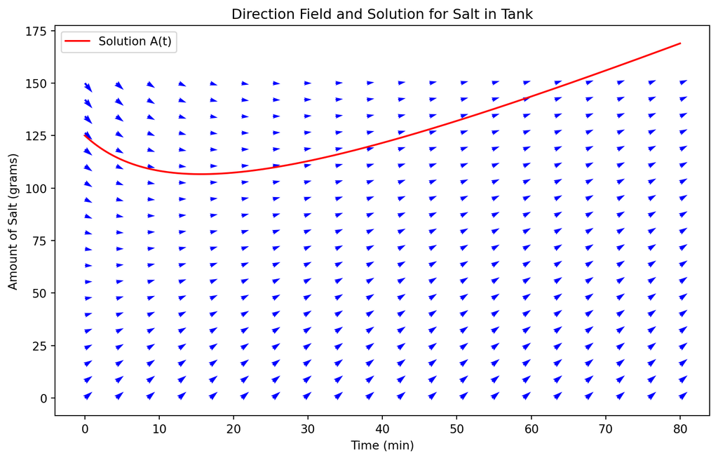

```python
import numpy as np
import matplotlib.pyplot as plt

# Constants
flow_in = 0.5  # m^3/min (inflow)
flow_out = 0.25  # m^3/min (outflow)
V_initial = 5  # m^3 (initial volume)
A_initial = 125  # grams (initial salt amount)
concentration_in = 6  # g/m^3

# Time range for solution
t = np.linspace(0, 80, 800)  # Time in minutes

# Function to compute the volume of the tank at time t
def volume(t):
    return V_initial + (flow_in - flow_out) * t

# Differential equation: dA/dt = inflow rate - outflow rate
def dA_dt(A, V):
    return flow_in * concentration_in - flow_out * A / V

# Solve the differential equation using Euler's method
A = np.zeros_like(t)
A[0] = A_initial  # Initial amount of salt

for i in range(1, len(t)):
    dt = t[i] - t[i - 1]
    A[i] = A[i - 1] + dA_dt(A[i - 1], volume(t[i - 1])) * dt

# Create a direction field for visualization
T, A_grid = np.meshgrid(np.linspace(0, 80, 20), np.linspace(0, 150, 20))
V_grid = volume(T)
dA = flow_in * concentration_in - flow_out * A_grid / V_grid

# Plot the direction field and the solution curve
fig, ax = plt.subplots(figsize=(10, 6))
ax.quiver(T, A_grid, np.ones_like(dA), dA, angles='xy', scale_units='xy', scale=1, color='blue')
ax.plot(t, A, color='red', label='Solution A(t)')
ax.set_xlabel('Time (min)')
ax.set_ylabel('Amount of Salt (grams)')
ax.set_title('Direction Field and Solution for Salt in Tank')
ax.legend()
plt.show()
```

### **Final Answer:**

- **(a):** The IVP is $\frac{dA}{dt} = 3 - 0.25 \cdot \frac{A(t)}{5 + 0.25t}, \quad A(0) = 125$.
- **(b):** The solution is $A(t) = \frac{15t + 0.375t^2 + 625}{5 + 0.25t}$, valid for $t \leq 80 \, \text{min}$.
- **(c):** The least amount of salt is approximately **106.75 grams**, which occurs at $t \approx 15.59 \, \text{min}$.
- **(d):** The direction field plot shows how the salt content evolves over time, with the solution curve representing the salt content decreasing to a minimum of about 106.75 grams before increasing again. :::

**Problem**